# FordGoBikePart2 slides

## Jee Naughton

FordGoBike Project Ford GoBike is the Bay Area's bike share system. Bay Area Bike Share was introduced in 2013 as a pilot program for the region, with 700 bikes and 70 stations across San Francisco and San Jose. By the end of 2018, Ford GoBike will grow to 7,000 bikes across San Francisco, the East Bay and San Jose.is the Bay Area's new bike share system, with thousands of public bikes for use across the greater San Francisco Bay area. An app was also created to co-piloting for getting around town. Ford has also introduced an ebike called Ford GoBike Plus on April 24th 2018 which is a motorized bike rides. We assume that this would attract more people to ride the bikes without breaking a sweat. For more information on this program, please go to https://www.fordgobike.com I have divided this project into 2 parts:

#### Dataset Overview

- FordGBPart1 - covers data from July 2017 till Jan 1st 2018 (2017-fordgobike-tripdata.csv)
- FordGoBikePart2 - covers data in 2018 (df_2018.csv)

#### This is the second part of the FordGoBike Project.

### Investigative Overview

- We will answer these questions as we go along and lastly, we will be comparing performance in the year 2018.
  1. When the most trips taken in terms of times of the day, day of the week, or month of the year?
  2. How long does the average trip take?
  3. Does the above depend on if a user is a customer or subscriber?
  4. Is there a pattern that is recognized during the advent of the ebike introduced in April 2018?

[figure not shown]

- This is a map of the Bike Stations in San Francisco Bay Area
- Ever since the introduction of the ebike in April 2018, you will notice that the trend has been rising. And again, the trend went down from November till January because the weather was cold.
- Comparing the trends in both years, they have the same shape and they both dip in rides around December and January for the cold winter weather.

[figure not shown]

- There is a significant difference between males and females and other riders from both years. The total number of riders are lower in 2017 because data was only gathered from July

[figure not shown]

- The percentage of all bikes rides are busier on Tuesdays and Wednesdays

[figure not shown]

### Most number of riders in the Age Group Category

[figure not shown]

- The most heavy use of the bikes are at 8am - 9 am and 5pm and 6pm. This is the assumption of going to work and returning from work.

[figure not shown]

#### Percentage of all bike rides per group

- Notice tha increase in use from April to May was because of the ebikes (2018) and the heaviest use of the bikes for the year is in October. then, in November and December, it was lower because of the cold (in both 2017 and 2018).

[figure not shown]

  Here are a few key reasons why you see increase in some months:
- This Women's Bike Month, Get a Free Ford GoBike Ride and $1 Per New Rider is Donated to SchoolCycle, a Girl Up Initiative, So Young Women Can Stay In School And Ride Towards A Better Future - October 2018
- Ford GoBike Rides Will be Free on Bike to Work Day May 8, 2018 -System Reaches Key Milestone of One Million Rides
- Motivate Adds New Pedal-Assist Ebikes to Ford GoBike System in San Francisco April 24, 2018

[figure not shown]

- We can again see the bike ride trends came from the group between the ages of 31-40

[figure not shown]

- The monthly user type was from subscribers more than customers. Please note that in october 2018, there was a slight bump in rides because Ford celebrates Women's Bike Month, Get a Free Ford GoBike Ride and $1 Per New Rider is Donated to SchoolCycle, a Girl Up Initiative, So Young Women Can Stay In School And Ride Towards A Better Future

[figure not shown]

- Both years Average trip duration per user type are identical with Customers averaging more duration than Subscribers

[figure not shown]

- Age groups between 31-40 came close with ages of 21-30 and overlaps in bike rides during october, november and december for subscribers in 2018

[figure not shown]

- Ages between 21-30 and 31-40 overlaps almost consistently but between july and october, there were more 21-30's for customers category in 2018

[figure not shown]

- There were more customers than subscribers in terms of distance covered but subscribers have more frequency in the number of trips because they have a shorter distance to cover.

[figure not shown]

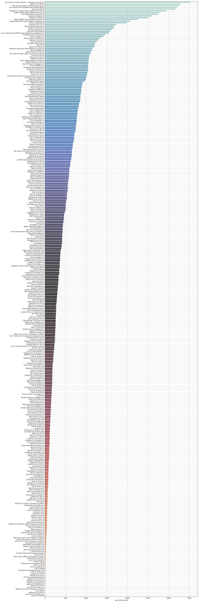

```python
plt.figure(figsize=(20,80))
data=df.start_station_name.value_counts()
sb.barplot(y=data.index, x = data, orient='h',palette='icefire')
plt.grid()
plt.savefig('pic27.png')
```

- These are the top Stations in San Francisco. They are identical in 2017 and 2018

[figure not shown]

#### Final summary

- This project is a win - win situation where everybody benefits from this program. Not only does the city gains it's recognition for people service oriented.
- Benefit from a healthier lifestyle
- Affordable transportation for the masses
- Inclined for the school kids to stay in school
- As a result, many other cities are following it's footsteps, examples are: Bike Share Toronto BIXI Montréal Blue Bikes (Boston) Capital Bikeshare (Washington D.C.) Citi Bike (New York City) Divvy (Chicago) Ford GoBike (San Francisco Bay Area) Melbourne Bike Share Nice Ride Minnesota Santander Cycles (London)